# Análisis exploratorio de datos de pedodiversidad

Carlos Manuel Guío Blanco

En este cuaderno se presenta un análisis exploratorio de los datos de pedodiversidad (Q de Rao) por Unidad Cartográfica de Suelos (UCS), calculada con base en distancias taxonómicas en la nomenclatura de suelos, y sus proporciones.

## 1. Carga de datos

Cargamos la capa espacial de unidades cartográficas de suelos (UCS) procesada previamente (y almacenada en Zenodo) y la depuramos (geometrías válidas, eliminación de vacíos). Esto establece la base espacial sobre la que se calcularán todas las métricas de pedodiversidad.

```r
# Corre script externo para cargar
source(here::here("Scripts", "00_funcion_carga_ucs_procesadas_qs.R"), encoding = "UTF-8")
```

```
Descargando archivo desde Zenodo con método 'curl'...
```

[output not shown]

[output cut: 592 more lines]

```
Tamaño del archivo descargado: 212.9 MB
CRS detectado: MAGNA-SIRGAS 2018 / Origen-Nacional (EPSG:9377)
```

```r
# Asignación de id único para cada polígono
ucs_sf_4326 <- ucs_rao_sf |>
  sf::st_make_valid() |> #valida geometrias problemáticas
  sf::st_transform(4326) |> # Transforma a crs 4326
  dplyr::select(id_creado, UCSuelo, AREA_HA, Q)

ucs_sf_4326 <- ucs_sf_4326[!st_is_empty(ucs_sf_4326), ]
```

```r
# Paletas continuas y discretas
pal_resp <- paletteer::paletteer_c("grDevices::Zissou 1", 100)
pal_qualitat <- paletteer::paletteer_d("wesanderson::Zissou1", 5)
```

## 2. Análisis descriptivo

Se realiza análisis descriptivo para:

- Comprender la distribución de los datos
- Identificar la relación con las áreas de unidades cartográficas, para definir necesidades de normalización, derivación de nuevas variables (e.g. residuales) y metodologías de análisis de patrones de puntos.
- Identificar relaciones potenciales con otras variables.

### 2.1 Distribución de la diversidad (Q), del área (A) y su relación

Generamos las variables de respuesta que se usarán en el resto del análisis (densidad de diversidad, transformaciones logarítmicas, etc.). Estas transformaciones minimizan sesgo y facilitan la comparación entre unidades de distinto tamaño. Para evitar −Inf en transformaciones logarítmicas: Q se fuerza a un mínimo de 1 × 10⁻³ (diversidad no nula).

```r
#Se crea una variable Qdens que expresa la densidad de Q
ucs_rao_sf_4326 <- ucs_sf_4326 |>
  tidyr::drop_na(Q) |>
  # se deja un mínimo diferente de cero para trabajar con logaritmos
  mutate(
    Q = if_else(Q == 0, 1e-3, Q),              # Evita log(0)
    Qdens = Q / AREA_HA,                       # Densidad de diversidad
    Q_squared = Q^2,
    log_A = log10(AREA_HA),
    log_Qdens = log10(Qdens)
    )
```

Calculamos estadística descriptiva básica y momentos de la distribución (CV, sesgo, curtosis) para evaluar la dispersión y asimetría de las variables clave antes de modelar.

```r
# Se transforma a df para usar en skimr
ucs_rao_df <- sf::st_drop_geometry(ucs_rao_sf_4326)

# Variables de interés
vars <- c("Q", "AREA_HA", "Qdens", "log_Qdens")

# Estadística descriptiva rápida
skimr::skim(ucs_rao_df[, vars])
```

```
── Data Summary ────────────────────────
                           Values
Name                       ucs_rao_df[, vars]
Number of rows             31111
Number of columns          4
_______________________
Column type frequency:
  numeric                  4
________________________
Group variables            None
```

|  | skim_variable | n_missing | complete_rate | mean | sd | p0 | p25 | p50 | p75 | p100 | hist |
| --- | --- | --- | --- | --- | --- | --- | --- | --- | --- | --- | --- |
| 1 | Q | 0 | 1 | 0.34630423 | 0.1812498 | 1.000000e-03 | 0.2222221111 | 3.912500e-01 | 4.938271e-01 | 6.666667e-01 | ▅▃▅▇▂ |
| 2 | AREA_HA | 0 | 1 | 1467.09436868 | 4889.1616504 | 1.764662e-02 | 92.3765540552 | 3.250327e+02 | 1.082889e+03 | 1.989815e+05 | ▇▁▁▁▁ |
| 3 | Qdens | 0 | 1 | 0.02025647 | 0.1605976 | 8.813263e-09 | 0.0001693237 | 8.086422e-04 | 3.303635e-03 | 1.110868e+01 | ▇▁▁▁▁ |
| 4 | log_Qdens | 0 | 1 | -3.18561633 | 1.2231218 | -8.054863e+00 | -3.7712823809 | -3.092244e+00 | -2.481008e+00 | 1.045662e+00 | ▁▂▇▃▁ |

```r
# Tabla resumen con CV, sesgo y curtosis
stats_summary <- vars |>
  setNames(vars) |>
  lapply(function(var) {
    x <- ucs_rao_df[[var]]
    x <- x[!is.na(x)]
    data.frame(
      variable = var,
      cv        = sd(x) / mean(x),
      skewness  = skewness(x, type = 2),     # tipo 2: Fisher (media = 0 para normal)
      kurtosis  = kurtosis(x, type = 2) - 3  # restar 3 para curtosis "exceso"
    )
  }) |>
  bind_rows()

print(stats_summary)
```

| variable | cv | skewness | kurtosis |
| --- | --- | --- | --- |
| Q | 0.5233830 | -0.6409716 | -3.763966 |
| AREA_HA | 3.3325475 | 15.1040993 | 381.762775 |
| Qdens | 7.9282125 | 30.7844436 | 1558.546452 |
| log_Qdens | -0.3839514 | -0.4410149 | -2.202509 |

```r
NA
```

Interpertación: Coeficiente de variación (cv) Mide la dispersión relativa respecto a la media.

- CV > 1: variable muy dispersa o con colas largas (potencialmente requiere transformación o uso de pesos en modelos).
- CV < 1: variable relativamente estable, menos problemática.
2. Skewness (sesgo): Mide la asimetría de la distribución:
- Skewness ≈ 0: simétrica (ideal para muchos modelos).
- Skewness < 0: sesgo a la izquierda (cola hacia valores bajos).
- Skewness > 0: sesgo a la derecha (cola hacia valores altos).

Valores absolutos > 1 suelen indicar asimetría significativa, y > 2 muy fuerte.

3. Kurtosis (curtosis): Mide la “altura” de la campana y la presencia de colas/extremos:
- Kurtosis ≈ 0 (normalizada): similar a la normal.
- Kurtosis > 0: distribución picuda, colas pesadas.
- Kurtosis < 0: distribución achatada, menos colas/extremos que la normal.

De acuerdo a esto, Log(Q/A) es la variable más adecuada para modelado, análisis espacial y definición de hotspots: dispersión controlada, sin colas largas, sesgo leve, apta para transformaciones lineales y GLM familia gaussiana (o beta si se normaliza a [0,1]).

Definimos los límites de Tukey (IQR ± 1.5) para detectar posibles valores atípicos en cada métrica. Estos límites se usarán como guías visuales en los histogramas posteriores.

```r
# Tukey limits for Q
q25_q <- quantile(ucs_rao_df$Q, 0.25, na.rm = TRUE)
q75_q <- quantile(ucs_rao_df$Q, 0.75, na.rm = TRUE)
iqr_q <- q75_q - q25_q
tukey_low_q  <- q25_q - 1.5 * iqr_q
tukey_high_q <- q75_q + 1.5 * iqr_q

# Tukey para Q_squared
q25_q2 <- quantile(ucs_rao_df$Q_squared, 0.25, na.rm = TRUE)
q75_q2 <- quantile(ucs_rao_df$Q_squared, 0.75, na.rm = TRUE)
iqr_q2 <- q75_q2 - q25_q2
tukey_low_q2  <- q25_q2 - 1.5 * iqr_q2
tukey_high_q2 <- q75_q2 + 1.5 * iqr_q2

# Tukey para AREA_HA
q25_a <- quantile(ucs_rao_df$AREA_HA, 0.25, na.rm = TRUE)
q75_a <- quantile(ucs_rao_df$AREA_HA, 0.75, na.rm = TRUE)
iqr_a <- q75_a - q25_a
tukey_low_a  <- q25_a - 1.5 * iqr_a
tukey_high_a <- q75_a + 1.5 * iqr_a

# Tukey para log_A
q25_la <- quantile(ucs_rao_df$log_A, 0.25, na.rm = TRUE)
q75_la <- quantile(ucs_rao_df$log_A, 0.75, na.rm = TRUE)
iqr_la <- q75_la - q25_la
tukey_low_la  <- q25_la - 1.5 * iqr_la
tukey_high_la <- q75_la + 1.5 * iqr_la

# Tukey limits for Qdens
q25_qd <- quantile(ucs_rao_df$Qdens, 0.25, na.rm = TRUE)
q75_qd <- quantile(ucs_rao_df$Qdens, 0.75, na.rm = TRUE)
iqr_qd <- q75_qd - q25_qd
tukey_low_qd  <- q25_qd - 1.5 * iqr_qd
tukey_high_qd <- q75_qd + 1.5 * iqr_qd

# Tukey para log_Qdens
q25_lqd <- quantile(ucs_rao_df$log_Qdens, 0.25, na.rm = TRUE)
q75_lqd <- quantile(ucs_rao_df$log_Qdens, 0.75, na.rm = TRUE)
iqr_lqd <- q75_lqd - q25_lqd
tukey_low_lqd  <- q25_lqd - 1.5 * iqr_lqd
tukey_high_lqd <- q75_lqd + 1.5 * iqr_lqd
```

### 2.2 Visualización de distribuciones

Exploramos las distribuciones univariadas mediante histogramas y densidades, superponiendo los límites de Tukey para identificar asimetrías y outliers de forma gráfica.

Para cada variable continua se construyen histogramas con barras azules y la curva de densidad re-escalada en amarillo. La barra negra horizontal y el punto central marcan el intervalo inter-cuartílico y la mediana, mientras que las líneas grises punteadas corresponden a los límites de Tukey para detección de valores atípicos. Este bloque permite evaluar asimetrías, colas largas y confirmar si son necesarias transformaciones (p. ej. log₁₀ o potencias) antes de la modelación.

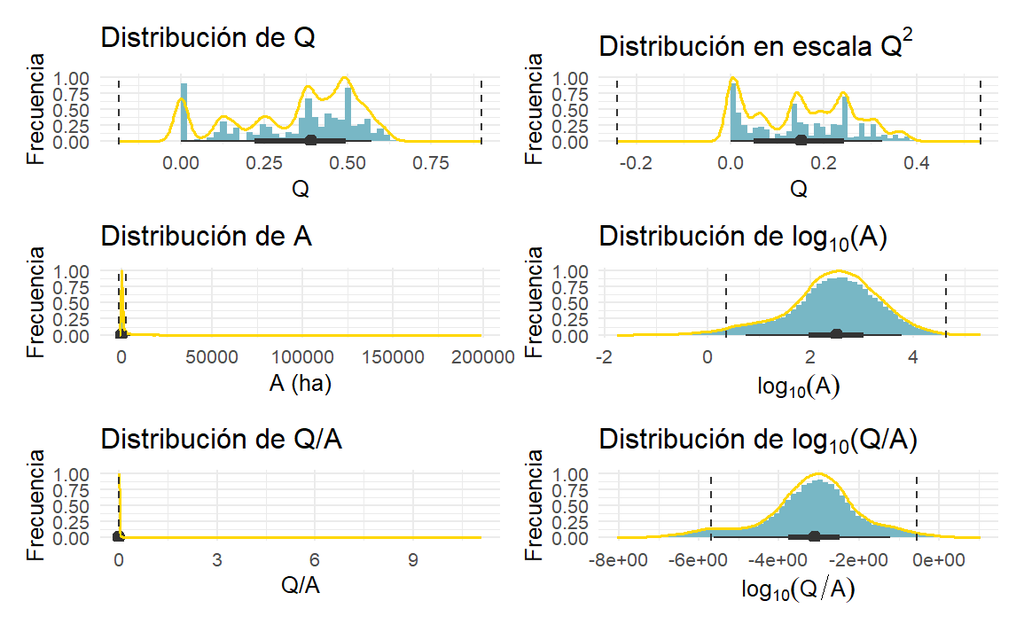

```r
# ─────────────────────────────────────────────────────────────────────────────
# FUNCIÓN utilitaria  ▸ histo_resp()
#   • variable (tidy-eval) a graficar
#   • título y etiqueta eje-X
#   • fences Tukey (inferior y superior)
#   • opcional: transformar eje-X (p.e. scientific / comma)
#   • opcional: binwidth o bins (si necesitas forzar uno)
# ─────────────────────────────────────────────────────────────────────────────

histo_resp <- function(df, var, title, xlab,
                       fence_low, fence_hi,
                       bins = NULL, binwidth = NULL,
                       x_scale = NULL) {

  g <- ggplot(df, aes({{ var }})) +
    ggdist::stat_histinterval(
      fill = pal_qualitat[2], colour = "grey20",
      .width = c(0.5, 0.9),
      bins = bins, binwidth = binwidth
    ) +
    geom_density(aes(y = after_stat(scaled)),
                 colour = "#FFD700", linewidth = 0.8) +
    geom_vline(xintercept = fence_low, linetype = "dashed", colour = "grey20") +
    geom_vline(xintercept = fence_hi,  linetype = "dashed", colour = "grey20") +
    labs(title = title, x = xlab, y = "Frecuencia") +
    theme_minimal(base_size = 12)

  if (!is.null(x_scale)) g <- g + x_scale
  g
}

# --- Histogramas --------------------------------------------------------------
p_Q   <- histo_resp(ucs_rao_sf_4326, Q,
                    "Distribución de Q", "Q",
                    tukey_low_q, tukey_high_q)
p_Q2  <- histo_resp(ucs_rao_sf_4326, Q_squared,
                    expression("Distribución en escala " * Q^2), "Q",
                    tukey_low_q2, tukey_high_q2)
p_A   <- histo_resp(ucs_rao_sf_4326, AREA_HA,
                    "Distribución de A", "A (ha)",
                    tukey_low_a, tukey_high_a)
p_logA <- histo_resp(
  ucs_rao_sf_4326, log_A,
  expression("Distribución de log"[10] * "(A)"),       # ← título con subíndice
  expression(log[10](A)),                              # ← eje X con subíndice
  tukey_low_la, tukey_high_la,
  x_scale = scale_x_continuous(
    breaks = scales::trans_breaks("identity", identity),
    labels = scales::label_comma()
  )
)
p_Qdens <- histo_resp(ucs_rao_sf_4326, Qdens,
                      "Distribución de Q/A", "Q/A",
                      tukey_low_qd, tukey_high_qd)
p_logQdens <- histo_resp(
  ucs_rao_sf_4326, log_Qdens,
  expression("Distribución de log"[10] * "(Q/A)"),     # ← título con subíndice
  expression(log[10](Q/A)),                            # ← eje X con subíndice
  tukey_low_lqd, tukey_high_lqd,
  x_scale = scale_x_continuous(
    breaks = scales::trans_breaks("identity", identity),
    labels = scales::label_scientific()
  )
)
# --- Mosaico 3 × 2 (sin cambios de estructura) --------------------------------
p_mosaico_respuesta <- (p_Q | p_Q2) /
                       (p_A | p_logA) /
                       (p_Qdens | p_logQdens)

ggsave(
  here::here("Figures", "mosaico_histogramas_respuesta.png"),
  plot   = p_mosaico_respuesta,
  width  = 9, height = 9, dpi = 350
)

p_mosaico_respuesta
```

### 2.3 Representación espacial de la variable respuesta

Visualizamos la variación espacial de cada métrica de diversidad (Q, Q², Q/A, log10(Q/A)) con mapas coropléticos uniformes en escala de color, lo cual facilita detectar patrones regionales.

```r
# Función genérica de mapa ----------------------------------------------------

map_resp <- function(df, var, title_expr, legend_lab,
                     trans      = "identity",
                     breaks     = waiver(),
                     labels_fn  = waiver()) {

  ggplot(df) +
    geom_sf(aes(fill = {{ var }}), colour = NA) +
    scale_fill_gradientn(
      colours  = pal_resp,
      na.value = "white",
      trans    = trans,
      guide    = guide_colourbar(
                  direction      = "vertical",
                  barwidth       = unit(0.25, "cm"),
                  barheight      = unit(3.5,  "cm"),
                  title.position = "top"),
      name     = legend_lab,
      breaks   = breaks,
      labels   = labels_fn
    ) +
    labs(title = title_expr) +
    theme_minimal() +
    theme(legend.justification = c("right", "top"))
}

# Cuatro mapas ----------------------------------------------------------------

# Q (lineal)
p_map_Q <- map_resp(
  ucs_rao_sf_4326, Q,
  "Mapa de Q", "Q"
)

# Q²
p_map_Q2 <- map_resp(
  ucs_rao_sf_4326, Q,
  expression("Mapa en escala " * Q^2), "Q",
  trans = ggforce::power_trans(2)          # Q²
)

# Q/A (lineal)
p_map_Qdens <- map_resp(
  ucs_rao_sf_4326, Qdens,
  "Mapa de Q/A", "Q/A"
)

## cortes automáticos dentro del rango de Qdens
# se toman 4 cortes log-espaciados (base-10) que caigan dentro del rango real
rng_qd      <- range(ucs_rao_sf_4326$Qdens, na.rm = TRUE)
log_breaks  <- scales::log_breaks(n = 4)(rng_qd)   # vector de cortes en escala original

p_map_logQdens <- map_resp(
  ucs_rao_sf_4326, Qdens,
  expression("Mapa en escala log"[10] * "(Q/A)"), "Q/A",
  trans     = "log10",
  breaks    = log_breaks,
  labels_fn = scales::label_scientific()
)

# Mosaico 2 × 2 y guardado -----------------------------------------------------

p_mapas_respuesta <- (p_map_Q | p_map_Q2) /
                     (p_map_Qdens | p_map_logQdens)

ggsave(
  here::here("Figures", "mapas_respuesta.png"),
  plot   = p_mapas_respuesta,
  width  = 8, height = 9, dpi = 350
)

#p_mapas_respuesta
```

[output not shown]

Se crea una gráfica final para el artículo

```r
p_respuesta_eda <- (p_Q | p_logQdens) / (p_map_Q  | p_map_logQdens) + plot_layout(heights = c(1, 3))

ggsave(
  here::here("Figures", "var_respuesta_eda.png"),
  plot   = p_respuesta_eda,
  width  = 10, height = 10, dpi = 350
)
```

### 2.4 Cuantificar el efecto del área

Analizamos la relación bivariada entre la diversidad (Q) y el área (A) en escalas lineal y logarítmica para verificar la necesidad de densificar o residuar Q respecto a A.

```r
# ── Scatterplot 1 · Q vs A (escala original) ────────────────────────────────
p_puntos_Q_A <- ggplot(ucs_rao_sf,
                       aes(x = AREA_HA, y = Q)) +
  geom_point(alpha = 0.5, colour = "#56B4E9") +
  labs(title = "Relación entre Q y A",
       x = "A (ha)",
       y = "Q") +
  theme_minimal(base_size = 12)

# ── Scatterplot 2 · log10(Q) vs log10(A) ────────────────────────────────────
p_puntos_logQ_logA <- ggplot(ucs_rao_sf,
                             aes(x = AREA_HA, y = Q)) +
  geom_point(alpha = 0.5, colour = "#56B4E9") +
  scale_x_log10(name = expression(log[10](A))) +
  scale_y_log10(name = expression(log[10](Q))) +
  labs(title = expression("Relación log"[10] * "(Q) y log"[10] * "(A)")) +
  theme_minimal(base_size = 12)

# ── Mosaico (dos columnas) y guardado ───────────────────────────────────────

p_dispersion_Q_A <- p_puntos_Q_A | p_puntos_logQ_logA

ggsave(
  here::here("Figures", "dispersion_Q_A.png"),
  plot   = p_dispersion_Q_A,
  width  = 7, height = 5, dpi = 350
)
```

Se calcula eñ coeficiente de correlación entre pedodiversidad y área, el cual es una meidida estadística que evalúa la fuerza y dirección de la relación monótona entre dos variables, ya sean continuas o discretas. A diferencia del coeficiente de correlación de Pearson, que mide relaciones lineales, Spearman se enfoca en relaciones que pueden ser monótonas, es decir, que siguen una tendencia creciente o decreciente, pero no necesariamente lineal. Este resultado sustenta el paso posterior de normalización por área.

```r
cor(ucs_rao_sf_4326$Q, ucs_rao_sf_4326$AREA_HA, use = "complete.obs", method = "spearman")
```

[output not shown]

### 3.4 Relación con otras variables

Comparamos la diversidad de suelos entre categorías de paisaje mediante histogramas y boxplots combinados, lo que permite evaluar si ciertos paisajes concentran mayor pedodiversidad.

```r
ggplot(ucs_rao_sf_4326 |> tidyr::drop_na(), aes(y = Q, x = PAISAJE)) +
  stat_histinterval(binwidth = 0.02,
                   alpha = 0.7,
                   fill = "#56B4E9",
                   color = "white",
                   slab_color = NA) +
  geom_boxplot(width = 0.05, outlier.shape = NA, alpha = 0.7, fill = "gray50") +
  theme_minimal() +
  labs(title = "Distribución de Rao Q por paisaje",
       y = "Rao Q", x = "Paisaje") +
  theme(axis.text.x = element_text(angle = 90, hjust = 1, vjust = 0.5))
```

[output not shown]

Repetimos el análisis anterior, pero estratificado por macro-clima, con el fin de explorar la influencia climática sobre la diversidad taxonómica de suelos.

```r
ggplot(ucs_rao_sf_4326 |> tidyr::drop_na(), aes(y = Q, x = CLIMA_1)) +
  stat_histinterval(binwidth = 0.02,
                   alpha = 0.7,
                   fill = "#56B4E9",
                   color = "white",
                   slab_color = NA) +
  geom_boxplot(width = 0.05, outlier.shape = NA, alpha = 0.7, fill = "gray50") +
  theme_minimal() +
  labs(title = "Distribución de Rao Q por clima",
       y = "Rao Q", x = "Clima") +
  theme(axis.text.x = element_text(angle = 90, hjust = 1, vjust = 0.5))
```

[output not shown]

Finalmente, inspeccionamos la diversidad según el régimen de humedad del suelo, buscando indicios de control edafoclimático en la variabilidad observada.

```r
ggplot(ucs_rao_sf_4326 |> tidyr::drop_na(), aes(y = Q, x = HUMEDAD)) +
  stat_histinterval(binwidth = 0.02,
                   alpha = 0.7,
                   fill = "#56B4E9",
                   color = "white",
                   slab_color = NA) +
  geom_boxplot(width = 0.05, outlier.shape = NA, alpha = 0.7, fill = "gray50") +
  theme_minimal() +
  labs(title = "Distribución de Rao Q por régimen de humedad",
       y = "Rao Q", x = "Régimen de humedad") +
  theme(axis.text.x = element_text(angle = 90, hjust = 1, vjust = 0.5))
```

[output not shown]